# Project - Computer Vision - 2

## by HARI SAMYNAATH S

```python
import numpy as np
import pandas as pd
import matplotlib.pyplot as plt
import cv2, warnings, os, pickle, datetime, zipfile, re
from PIL import Image
from tqdm import tqdm
warnings.filterwarnings("ignore")
```

```python
from tensorflow.keras.applications.mobilenet import MobileNet
from tensorflow.keras.applications.mobilenet import preprocess_input
from tensorflow.keras.layers import Concatenate, Conv2D, Reshape, UpSampling2D, Convolution2DTranspose
from tensorflow.keras.models import Sequential
from tensorflow.keras.layers import ZeroPadding2D, Convolution2D, MaxPooling2D, Dropout, Flatten, Activation
from tensorflow.keras.models import Model
from tensorflow.keras.utils import plot_model
from tensorflow.keras import optimizers, regularizers
from tensorboard.plugins.hparams import api as hp
from tensorflow.keras.models import load_model
from tensorflow.keras import backend
import tensorflow as tf
```

```python
from sklearn.preprocessing import StandardScaler
from sklearn.model_selection import train_test_split
from sklearn.svm import SVC
from sklearn.decomposition import PCA
from sklearn.preprocessing import LabelEncoder
```

### user defined methods / classes

```python
def gridConsolidate(pgrid,sLogFile,verbose=True):
    """read gridsearch log file,
    update local log,
    identify prerun gridpoints
    trim gridpoints
    """

    gridRuns = [] # reset local log

    # read the tuning log (if any)
    file = open(sLogFile,'rb')
    read = True
    while read:
        try:
            gridRuns.append(pickle.load(file))
        except:
            read = False
    file.close()

    # list previously searched grids
    if len(gridRuns)>0:
        grids = [i[:-3] for i in gridRuns]
    else:
        grids = []

    # delete pre-evaluated gridpoints (if any)
    for gp in grids:
        peGrid = dict(zip(pnames,gp))
        try:
            pgrid.remove(peGrid)
        except:
            pass

    if verbose:
        print("grid points remaining: ",len(pgrid))

    return pgrid,gridRuns
```

```python
# customised learning rate scheduler
# considering slope of validation loss
class lossGradientLR(tf.keras.callbacks.Callback):
    """gradually descend learning rate if the loss defined my the model is not descending at desired rate"""
    def __init__(self,initial_learning_rate=1e-3,patience=5,
                 slope=0.25,factor=0.75,lr_least=1e-10,verbose=False):
        super(lossGradientLR, self).__init__()
        self.initial_learning_rate = initial_learning_rate
        self.patience = patience
        self.slope = -slope
        self.factor = factor
        self.lr_least = lr_least
        self.verbose = verbose
        self.loss = []
        self.lr = [initial_learning_rate]
        self.lastAdjust = 0

    def Gradient_schedule(self,epoch):
        """scheduled learning rate manipulation"""
        flag1 = False
        flag1 = (epoch-self.lastAdjust)>self.patience # min epoch before adjust

        flag2 = False
        try:
            flag2 = (self.loss[-1]-self.loss[-2])>0 and (self.loss[-2]-self.loss[-3])>0
            # if two continuous epochs have increasing validation loss
        except:
            pass

        # slope of validation loss
        lossGrad = (self.loss[-1]-self.loss[self.lastAdjust])
        lossGrad/= len(self.loss[self.lastAdjust:])

        # if slope of validation loss not descending at slope or flag2
        if (flag1 and lossGrad>self.slope) or (flag2):
            self.lr.append(max(self.lr[-1]*self.factor,self.lr_least)) #min lr_least
            self.lastAdjust = epoch # update last adjust epoch

        if self.verbose:
            print("\n\nslopeOfLoss:%.2f"%lossGrad," @ epoch:%d"%epoch, "---- learning_rate:",self.lr[-1],"\n")

    def on_epoch_end(self,epoch,logs={}):
        """on end of each epoch"""
        # fetch validation loss
        self.loss.append(logs.get('val_loss'))
        #invoke learning rate calculator
        self.Gradient_schedule(epoch)

    def on_epoch_begin(self,epoch,logs={}):
        """beginning of each epoch"""
        # update model learning rate
        tf.keras.backend.set_value(self.model.optimizer.lr, self.lr[-1])

# report learning rate to tensorboard
# due to custom lr_scheduler
class LRTensorBoard(tf.keras.callbacks.TensorBoard):
    """report to tensorfboard about the updates created by lossGradientLR"""
    def __init__(self, log_dir, **kwargs):
        super().__init__(log_dir=log_dir, **kwargs)

    def on_epoch_end(self, epoch, logs=None):
        logs = logs or {}
        logs.update({'learning_rate': backend.eval(self.model.optimizer.learning_rate)})
        super().on_epoch_end(epoch, logs)
```

```python
def nnTrain(modelFunc, mNamePrefix, hparam, sLogFile, logBaseDir, loss, metrics,
            fitparams, htune=False, savePeak=False, eStop=False, verbose=0):
    """set up the environment and train the network
    modelFunc : function that creates a network architecture according to the passed parameters
    mNamePrefix : string identifier for naming
    hparam : dict of hyperparameter
    sLogFile : hyperparameter and results consolidation log file name with path
    logBaseDir : base directory of tensorboard logs
    loss : built-in loss or user defined loss function
    metrics : list of metrics to monitor
    fitparams : dict of kwargs to pass on to fit method except callbacks
    htune : boolean, enable/disable hypertuning callback
    savePeak : boolean, enable/disable saveBest callback
    eStop : boolean, enable/disable earlyStop callback
    verbose : 0,1,2 verbosity
    """
    # Random consistency seed
    np.random.seed(129)
    tf.random.set_seed(129)

    # create model
    model = modelFunc(hparam)

    # name it
    global gridRuns
    mname = mNamePrefix + "_%03d_"%(len(gridRuns)+1) + datetime.datetime.now().strftime("%d%b_%I%M%P")

    # create tensorboard logs & callbacks
    logdir = os.path.join(logBaseDir, mname)
    tensorboard_cb = tf.keras.callbacks.TensorBoard(logdir, histogram_freq=1, embeddings_freq=1)

    # initiate learning rate reporter
    lReport = LRTensorBoard(logdir)

    # learnin rate decay scheduler
    lr = hparam.get('learningRate')
    lr_schedule = lossGradientLR(lr,factor=0.1,verbose=bool(verbose))

    # callback to report hyperparameters to tensorboard
    hypertune = hp.KerasCallback(logdir,hparam)

    # metrics-->monitor
    if type(metrics[0])==str:
        nMonitor = metrics[0]
        monitor = "val_" + metrics[0]
    else:
        nMonitor = metrics[0].__name__
        monitor = "val_" + metrics[0].__name__

    # callback to save best model weights
    saveFile = logBaseDir + '/' + mname + '_weights.{epoch:02d}-{' + nMonitor + ':.2f}.h5'
    saveBest = tf.keras.callbacks.ModelCheckpoint(filepath=saveFile,monitor=monitor,
                                              mode='max',save_best_only=True)

    # early stop callback
    earlyStop = tf.keras.callbacks.EarlyStopping(monitor=monitor,mode='max',
                                                 min_delta=0.01,patience=15,restore_best_weights=True)

    # collect callbacks
    cbs = [tensorboard_cb,lr_schedule,lReport]
    cbs.append(hypertune) if htune else None
    cbs.append(saveBest) if savePeak else None
    cbs.append(earlyStop) if eStop else None

    # optimisers
    optim = optimizers.RMSprop(learning_rate=lr,rho=0.9,momentum=0.1, epsilon=1e-07)

    # compile model
    model.compile(optimizer=optim,loss=loss,metrics=metrics)

    # update fitparams
    fitparams.update(dict(callbacks=cbs,verbose=verbose))

    # model fitting
    with tf.device('/device:GPU:0'):
        logger = model.fit(**fitparams)

    # obtain peak results
    (p_metric,p_epoch) = (np.max(logger.history.get(monitor)),
                     np.argmax(logger.history.get(monitor)))

    # summarise hparams with results
    with tf.summary.create_file_writer(logBaseDir +'/hparam_tuning').as_default():
        hp.hparams(hparam)

    # log the results
    storage = []
    storage.extend(list(hparam.values()))
    storage.extend([p_metric,p_epoch])
    storage.extend([mname])

    file = open(sLogFile,'ab')
    pickle.dump(storage,file)
    file.close()

    pgrid,gridRuns = gridConsolidate(hparam,sLogFile,False)

    return model,logger, mname
```

```python
def hTune(modelFunc, mNamePrefix, pgrid, sLogFile, logBaseDir, nSearch, loss, metrics, fitparams):
    """Neural Networks HyperTuning function
    modelFunc : function that creates a network architecture according to the passed parameters
    mNamePrefix : string identifier for naming
    pgrid : list of gridpoints each as a dict of hyperparameter
    sLogFile : hyperparameter and results consolidation log file name with path
    logBaseDir : base directory of tensorboard logs
    nSearch : int, number of randome grid points to run gridsearch
    loss : built-in loss or user defined loss function
    metrics : list of metrics to monitor
    fitparams : dict of kwargs to pass on to fit method except callbacks
    """

    startTime = datetime.datetime.now()
    lapTime = startTime

    global gridRuns
    pgrid,gridRuns = gridConsolidate(pgrid,sLogFile, False)

    # metrics-->monitor
    if type(metrics[0])==str:
        nMonitor = metrics[0]
        monitor = "val_" + metrics[0]
    else:
        nMonitor = metrics[0].__name__
        monitor = "val_" + metrics[0].__name__

    for gp in np.random.choice(np.array(pgrid),nSearch,replace=False):

        # update fitparams for hypertuning with reduced dataset
        #fitparams.update(dict(steps_per_epoch = 8, validation_steps = 2))

        _, logger, _ = nnTrain(modelFunc, mNamePrefix, gp, sLogFile, logBaseDir, loss, metrics,
                fitparams, htune=True, savePeak=False, eStop=True, verbose=0)

        print("grid :%03d"%(len(gridRuns)+1))
        print("gridPoint:", gp)
        print(nMonitor + ':%.2f'%logger.history.get(nMonitor)[0] + ' '*8 +
              monitor + ':%.2f'%logger.history.get(monitor)[0])

        t2 = datetime.datetime.now() - lapTime
        th = int(t2.seconds/60/60)
        tm = int(np.mod(t2.seconds,3600)/60)
        ts = np.mod(t2.seconds,60)
        tstr1 = "elapsed lap time %02d:%02d:%02d"%(th,tm,ts)

        t2 = datetime.datetime.now() - startTime
        th = int(t2.seconds/60/60)
        tm = int(np.mod(t2.seconds,3600)/60)
        ts = np.mod(t2.seconds,60)
        tstr2 = "   elapsed total time %02d:%02d:%02d"%(th,tm,ts)

        print(tstr1, tstr2, '\n')

        lapTime = datetime.datetime.now()
```

## Part A

**DOMAIN:** Entertainment  
**• CONTEXT:** Company X owns a movie application and repository which caters to movie streaming to millions of users who are logged on subscription basis. Company wants to automate the process of cast and crew information in each scene from a movie such that when a user pauses on the movie and clicks on cast information button, the app will show details of the actor in the scene. Company has an in-house computer vision and multimedia experts team who need to detect faces from screen shots from the movie scene. The data labelling is already done, since there higher time complexity is involved  
**• DATA DESCRIPTION:** The dataset comprises of images and its mask for corresponding human face.  
**• PROJECT OBJECTIVE:**To build a face detection system.

**Steps and tasks:**

1. Import and Understand the data  
   A. Import and read ‘images.npy’.  
   B. Split the data into Features(X) & labels(Y). Unify shape of all the images.  
   Imp Note: Replace all the pixels within masked area with 1.  
   Hint: X will comprise of array of image whereas Y will comprise of coordinates of the mask(human face).  
   Observe: data[0], data[0][0], data[0][1].  
   C. Split the data into train and test[400:9].  
   D. Select random image from the train data and display original image and masked image.

```python
# load images.npy file (numpy arrays file)
images = np.load('images.npy',allow_pickle=True)
```

```python
# review shape of data
images.shape
```

```
(409, 2)
```

```python
# lets create function to display dimensions to study from the image dataset
def imsize(images):

    dh=[]
    dw=[]
    dc=[]
    ds=[]

    for i in images:
        try:
            (h,w,c)=i.shape
        except:
            (h,w)=i.shape
            c=1
        dh.append(h)
        dw.append(w)
        dc.append(c)
        ds.append(len(i.shape))

    minh = min(dh)
    minw = min(dw)
    minc = min(dc)
    mins = min(ds)

    maxh = max(dh)
    maxw = max(dw)
    maxc = max(dc)
    maxs = max(ds)

    # display the dimension limits
    print((minh,minw,minc,maxs,maxh,maxw,maxc,maxs))

    return dh,dw,dc,ds
```

```python
# review the dimensions of the images
dh,dw,dc,ds = imsize(images[:,0])
```

```
(180, 182, 1, 3, 4016, 6016, 4, 3)
```

the image size ranges from 180 to 6016 pixels in either directions  
it could be seen that there are single channel images as well as 4 channel images

```python
# split the images and labels
# also standardise the number of channels in each image
img = []
lab = []
msk = []
n4s = []
for n,[i,l] in enumerate(images):
    # check channels
    try:
        h,w,c = i.shape
    except: # single channel images
        h,w = i.shape
        nimg = np.zeros((h,w,3),dtype='uint8') # create 3 channels
        nimg[:,:,0] = i
        nimg[:,:,1] = i
        nimg[:,:,2] = i
        i = nimg
        h,w,c = i.shape
    if c!=3: # if number of channels more than 3
        n4s.append(n)

    # append images & labels
    img.append(i)
    lab.append(l)

    # create masked images
    mask = np.zeros((h,w),dtype='uint8')
    for box in l:
        a,b = np.multiply(list(box.get('points')[0].values()),[w,h]).astype(int)
        c,d = np.multiply(list(box.get('points')[1].values()),[w,h]).astype(int)
        cv2.rectangle(mask,(a,b),(c,d), 1, -1)

    # append masked images
    msk.append(mask)
```

```python
# verify if there are images with channels more than 3
print(len(n4s))
```

```
11
```

```python
# review 4th channels of those images
for i in n4s:
    print(i,img[i].shape, np.unique(img[i][:,:,3]))
```

```
1 (697, 1280, 4) [255]
3 (291, 600, 4) [255]
41 (340, 516, 4) [255]
49 (600, 800, 4) [255]
64 (312, 750, 4) [255]
140 (330, 538, 4) [255]
151 (496, 860, 4) [  0   2   4   6   8  10  12  14  16  18  20  22  23  25  27  29  31  33
  35  37  38  40  42  44  46  48  49  51  53  55  56  58  60  62  63  65
  67  69  70  72  74  75  77  79  80  82  84  85  87  89  90  92  93  95
  97  98 100 255]
247 (379, 505, 4) [255]
263 (400, 770, 4) [255]
337 (267, 740, 4) [255]
347 (281, 600, 4) [255]
```

almost every 4th channel is a plain white pixel, lets drop the same  
except for image 151, which contains certain other gray levels, lets review image 151

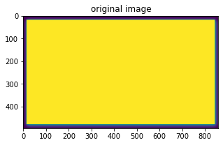

```python
# review the image 151 to verify
plt.figure(figsize=(5,5))
plt.title("original image")
plt.imshow(img[151][:,:,3])
```

the 4th channel in image 151 is a bounding box for the entire frame, which could also be droppped without affecting the quality of the image in other 3 channels

```python
# delete 4th channel in those images
for i in n4s:
    h,w,c = img[i].shape
    nimg = np.zeros((h,w,3),dtype='uint8') # create 3 channels
    nimg[:,:,0] = img[i][:,:,0]
    nimg[:,:,1] = img[i][:,:,1]
    nimg[:,:,2] = img[i][:,:,2]
    img[i] = nimg
```

```python
# review & store the dimensions limits before resizing
original_dims = imsize(img)
```

```
(180, 182, 3, 3, 4016, 6016, 3, 3)
```

[figure not shown]

```python
# preview a random image
np.random.seed(185)
ind = np.random.randint(0,409)
plt.figure(figsize=(15,45))
plt.subplot(131)
plt.title("original image")
plt.imshow(img[ind])
plt.subplot(132)
plt.title("mask")
plt.imshow(msk[ind])
plt.subplot(133)
plt.title("masked image")
masked = cv2.bitwise_and(img[ind],img[ind],mask=msk[ind])
plt.imshow(masked)
```

[figure not shown]

```python
# preview the image before & after resizing
plt.figure(figsize=(10,20))
plt.subplot(121)
plt.title("original image")
plt.imshow(img[ind])
plt.subplot(122)
plt.title("resized image")
plt.imshow(cv2.resize(img[ind],(128,128)))
```

```python
# Unify shape of all the images
# choosing 160 to suit MobileNet row recommended size
rimg = np.zeros_like(img)
rmsk = np.zeros_like(msk)
for i in range(409):
    xi = cv2.resize(img[i],(128,128)) # images
    rimg[i] = preprocess_input(np.array(xi, dtype=np.float32))

    rmsk[i] = cv2.resize(msk[i],(128,128)) # masks/bounding boxes
    rmsk[i] = (rmsk[i][:,:]>0.25)*1.0 # binary mask of float dtype
```

```python
# review & store the dimensions limits after resizing
resized_dims = imsize(rimg)
```

```
(128, 128, 3, 3, 128, 128, 3, 3)
```

```python
# split train & test
np.random.seed(129)
indices = np.random.choice(range(409),(9,9),replace=False) # train:validation:test::328:72:9
test_index = indices[0]
validation_index = np.unique(indices[1:])
train_images = []
train_masks = []
val_images = []
val_masks = []
test_images = []
test_masks = []
for i in range(409): # split
    if i in test_index:
        test_images.append(rimg[i])
        test_masks.append(rmsk[i])
    elif i in validation_index:
        val_images.append(rimg[i])
        val_masks.append(rmsk[i])
    else:
        train_images.append(rimg[i])
        train_masks.append(rmsk[i])

train_images = np.array(train_images)
train_masks = np.array(train_masks)
val_images = np.array(val_images)
val_masks = np.array(val_masks)
test_images = np.array(test_images)
test_masks = np.array(test_masks)
```

```
Clipping input data to the valid range for imshow with RGB data ([0..1] for floats or [0..255] for integers).
Clipping input data to the valid range for imshow with RGB data ([0..1] for floats or [0..255] for integers).
```

[figure not shown]

```python
# preview a random training image
np.random.seed(11)
ind = np.random.randint(0,400)
plt.figure(figsize=(15,45))
plt.subplot(131)
plt.title("resized image")
plt.imshow(train_images[ind])
plt.subplot(132)
plt.title("mask")
plt.imshow(train_masks[ind])
plt.subplot(133)
plt.title("masked image")
masked = cv2.bitwise_and(train_images[ind],train_images[ind],mask=train_masks[ind].astype('uint8'))
plt.imshow(masked)
```

the images appear darker as half of the color range have been clipped by pyplot imshow function  
though the image appears darker, the distribution of spatial pixel relations are retained in the floating point format available for the network to learn upon.

**Steps and tasks:**

1. Model building  
   A. Design a face mask detection model.  
   Hint: Use MobileNet architecture for initial pre-trained non-trainable layers.  
   Hint: Add appropriate Upsampling layers to imitate U-net architecture.  
   B. Design your own Dice Coefficient and Loss function.  
   C. Train and tune the model as required.  
   D. Evaluate and share insights on performance of the model.

```python
def dice(y,pred):
    return 2 * tf.reduce_sum(pred*y)/(tf.reduce_sum(pred+y)+1) #+1 as epsilon
```

```python
# test the dice coefficient function
print("same mask dice coeff: %.3f"%dice(train_masks[ind],train_masks[ind]).numpy())
print("2 diff mask dice coeff: %.3f"%dice(train_masks[ind],train_masks[ind+8]).numpy())
```

[output not shown]

```
same mask dice coeff: 1.000
2 diff mask dice coeff: 0.212
```

[output not shown]

same masks dice coefficient is slightly less than 1 due to +1 in the denominator

```python
def loss(y,pred):
    # cross entropy loss for classification
    l1 = tf.keras.losses.binary_crossentropy(y,pred)
    # log loss(negative) from dice coeficient
    l2 = -tf.keras.backend.log(dice(y,pred)+1e-37) #1e-37 as epsilon
    return l1+l2
```

```python
# test the loss function
print("same mask loss levels:\n",np.unique(loss(train_masks[ind].astype(float),train_masks[ind].astype(float)).numpy()))
print("2 diff mask loss levels:\n",np.unique(loss(train_masks[ind].astype(float),train_masks[ind+8].astype(float)).numpy()))
```

```
same mask loss levels:
 [0.00016468]
2 diff mask loss levels:
 [1.55095896 3.84059975 4.20212198 5.40719608 5.76871831 6.853285  ]
```

```python
# lets define a method to create the Unet architecture
def MobileUNET(params={}):
    """method to create MobileNet base Unet analogous neural topology"""
    # read parameters
    alpha,train_from,upConvFilter = list(params.values())[:3]

    # Random consistency seed
    np.random.seed(129)
    tf.random.set_seed(129)

    # define MobileNet as the skeleton for this Unet alias attempt
    model = MobileNet(input_shape=(128,128,3),include_top=False,alpha=alpha,weights='imagenet')

    # fetch skip connections for feature mapping
    skip1 = model.get_layer('conv_pw_1_relu').output
    skip2 = model.get_layer('conv_pw_3_relu').output
    skip3 = model.get_layer('conv_pw_5_relu').output
    skip4 = model.get_layer('conv_pw_11_relu').output

    # name & identitfy the bottle neck output
    bottleNeck = model.get_layer('conv_pw_13_relu').output

    # transposed convolutions and concatenations to upsample from bottleneck
    build4 = Convolution2DTranspose(upConvFilter,kernel_size=(3,3),strides=(2,2),
                                    padding='same',name='build_conv_4')(bottleNeck)
    cat4 = Concatenate(name='build_cat_4')([build4,skip4])
    build3 = Convolution2DTranspose(upConvFilter,kernel_size=(3,3),strides=(2,2),
                                    padding='same',name='build_conv_3')(cat4)
    cat3 = Concatenate(name='build_cat_3')([build3,skip3])
    build2 = Convolution2DTranspose(upConvFilter,kernel_size=(3,3),strides=(2,2),
                                    padding='same',name='build_conv_2')(cat3)
    cat2 = Concatenate(name='build_cat_2')([build2,skip2])
    build1 = Convolution2DTranspose(upConvFilter,kernel_size=(3,3),strides=(2,2),
                                    padding='same',name='build_conv_1')(cat2)
    cat1 = Concatenate(name='build_cat_1')([build1,skip1])

    build0 = Convolution2DTranspose(upConvFilter,kernel_size=(3,3),strides=(2,2),
                                    padding='same',name='build_conv_0')(cat1)

    # introduce a convolutional layer with sigmoid function to obtain the desired mask with 0~1
    conv_mask = Conv2D(1,kernel_size=1,activation='sigmoid',name='mask_generator')(build0) #(transConv)

    # reshape to desired shape
    mask_layer = Reshape((128,128),name='output')(conv_mask)

    model = Model(inputs = model.input, outputs = mask_layer)

    for l in model.layers[:train_from]:
        l.trainable=False

    return model
```

```python
# lets train a base model
param = dict(alpha=1,train_from=73,upConvFilter=64)
model = MobileUNET(param)
model.compile(loss=loss,metrics=[dice])
# create tensorboard logs & callbacks
logdir = "logs"
tensorboard = tf.keras.callbacks.TensorBoard(logdir, histogram_freq=1)

# Random consistency seed
np.random.seed(129)
tf.random.set_seed(129)

with tf.device('/device:GPU:0'):
    logger = model.fit(x=train_images,y=train_masks,epochs=1,
                       validation_data=(val_images,val_masks),callbacks=[tensorboard])
```

[output not shown]

```
2022-05-01 18:51:39.416687: W tensorflow/core/framework/cpu_allocator_impl.cc:82] Allocation of 251658240 exceeds 10% of free system memory.
```

```python
# review the model performance
logger.history
```

```
{'loss': [3.1688425540924072],
 'dice': [0.19510607421398163],
 'val_loss': [2.5280511379241943],
 'val_dice': [0.25105053186416626]}
```

lets hyoertune the model

```python
# lets define the hyperparameter grid points
alphas = [0.25,0.5,0.75,1]
trainables = [0,9,22,35,72,85]
filters = [2,4,16,32,64]
lrates = [1e-2,1e-3,1e-4,1e-5]

pnames = ['alpha','trainFrom','channels','learningRate']

pgrid = [dict(zip(pnames,[a,tl,f,lr]))
         for a in alphas
         for tl in trainables
         for f in filters
         for lr in lrates
        ]

print("number of grid points: ",len(pgrid))
```

```
number of grid points:  480
```

```python
# refer hypertuning log file and update local log & grid points
sLogFile = "logs/MobileUNet_tuning.har"
pgrid,gridRuns = gridConsolidate(pgrid,sLogFile)
```

```
grid points remaining:  319
```

```python
%load_ext tensorboard
%tensorboard --logdir logs
```

[interactive chart not shown]

```python
fitparams =  dict(x=train_images,y=train_masks,batch_size=24,epochs=20,
                           validation_data=(val_images,val_masks))

sLogFile = "logs/MobileUNet_tuning.har"

# lets perform hyperparameter random grid search using our custom functions
hTune(modelFunc=MobileUNET, mNamePrefix='Munet_tune', pgrid=pgrid, sLogFile=sLogFile,
      logBaseDir='logs', nSearch=2, loss=loss, metrics=[dice], fitparams=fitparams)
```

```
grid :172
gridPoint: {'alpha': 0.25, 'trainFrom': 85, 'channels': 64, 'learningRate': 0.001}
dice:0.19        val_dice:0.22
elapsed lap time 00:00:53    elapsed total time 00:00:53

grid :173
gridPoint: {'alpha': 0.75, 'trainFrom': 0, 'channels': 4, 'learningRate': 1e-05}
dice:0.16        val_dice:0.15
elapsed lap time 00:00:41    elapsed total time 00:01:34
```

```python
# lets review the hyperparameter tuning history in terms of top performers
cols = pnames.copy()
cols.extend(['dice','epoch','mname'])
resDf = pd.DataFrame(gridRuns,columns=cols).sort_values(by=["dice",'epoch'],ascending=False)
resDf = resDf[resDf.mname.str.contains('Munet_tune')] # eliminate other results
resDf.head()
```

|  | alpha | trainFrom | channels | learningRate | dice | epoch | mname |
| --- | --- | --- | --- | --- | --- | --- | --- |
| 0 | 1.00 | 9 | 32 | 0.010 | 0.678458 | 13 | Munet_tune_2212_29Apr_0143am |
| 1 | 1.00 | 22 | 16 | 0.001 | 0.655912 | 19 | Munet_tune_2851_29Apr_0148am |
| 2 | 0.75 | 0 | 32 | 0.001 | 0.654394 | 19 | Munet_tune_092_29Apr_0110am |
| 3 | 1.00 | 22 | 16 | 0.010 | 0.650976 | 13 | Munet_tune_407_29Apr_0120am |
| 4 | 1.00 | 9 | 4 | 0.001 | 0.649111 | 19 | Munet_tune_232_29Apr_0116am |

```python
resDf.sort_values(by=['epoch','dice'],ascending=False).head()
```

|  | alpha | trainFrom | channels | learningRate | dice | epoch | mname |
| --- | --- | --- | --- | --- | --- | --- | --- |
| 1 | 1.00 | 22 | 16 | 0.001 | 0.655912 | 19 | Munet_tune_2851_29Apr_0148am |
| 2 | 0.75 | 0 | 32 | 0.001 | 0.654394 | 19 | Munet_tune_092_29Apr_0110am |
| 4 | 1.00 | 9 | 4 | 0.001 | 0.649111 | 19 | Munet_tune_232_29Apr_0116am |
| 5 | 0.75 | 9 | 32 | 0.001 | 0.646866 | 19 | Munet_tune_3241_29Apr_0152am |
| 6 | 0.75 | 9 | 16 | 0.001 | 0.644933 | 19 | Munet_tune_011_29Apr_0104am |

```python
# select top performers
newGrid = []
resDf = resDf.sort_values(by=['dice','epoch'],ascending=False)
for i in range(2):
    newGrid.append(dict(zip(pnames,resDf.reset_index(drop=True).loc[i].values[:4])))
resDf.drop(resDf.head(2).index,inplace=True) # drop the pervious selections
resDf = resDf.sort_values(by=['epoch','dice'],ascending=False)
for i in range(2):
    newGrid.append(dict(zip(pnames,resDf.reset_index(drop=True).loc[i].values[:4])))
newGrid
```

```
[{'alpha': 1.0, 'trainFrom': 9, 'channels': 32, 'learningRate': 0.01},
 {'alpha': 1.0, 'trainFrom': 22, 'channels': 16, 'learningRate': 0.001},
 {'alpha': 0.75, 'trainFrom': 0, 'channels': 32, 'learningRate': 0.001},
 {'alpha': 1.0, 'trainFrom': 9, 'channels': 4, 'learningRate': 0.001}]
```

```python
%%time
fitparams =  dict(x=train_images,y=train_masks,batch_size=24,epochs=50,
                           validation_data=(val_images,val_masks))

sLogFile = "logs/MobileUNet_tuning.har"

tb50e_log = []

# lets train the chosen networks for 50 epoch each
for gp in newGrid:
    model,logger, mname = nnTrain(modelFunc=MobileUNET, mNamePrefix='Munet_50e', hparam=gp, sLogFile=sLogFile,
                                  logBaseDir='logs', loss=loss, metrics=[dice], fitparams=fitparams,
                                  htune=True, savePeak=False, eStop=True, verbose=0)
    tb50e_log.append([model,logger, mname])
    print(mname, 'dice:%.4f'%logger.history.get('dice')[0], 'val_dice:%.4f'%logger.history.get('val_dice')[0])
```

```
2022-05-01 18:53:27.197823: W tensorflow/core/framework/cpu_allocator_impl.cc:82] Allocation of 251658240 exceeds 10% of free system memory.
2022-05-01 18:53:30.373493: W tensorflow/core/framework/cpu_allocator_impl.cc:82] Allocation of 251658240 exceeds 10% of free system memory.
2022-05-01 18:53:33.539325: W tensorflow/core/framework/cpu_allocator_impl.cc:82] Allocation of 251658240 exceeds 10% of free system memory.
2022-05-01 18:53:36.684015: W tensorflow/core/framework/cpu_allocator_impl.cc:82] Allocation of 251658240 exceeds 10% of free system memory.
```

```
Munet_50e_173_01May_0653pm dice:0.1320 val_dice:0.2026
Munet_50e_174_01May_0655pm dice:0.2090 val_dice:0.2595
Munet_50e_175_01May_0656pm dice:0.2184 val_dice:0.2847
Munet_50e_176_01May_0657pm dice:0.2100 val_dice:0.2332
CPU times: user 6min 44s, sys: 51.3 s, total: 7min 35s
Wall time: 6min 13s
```

```python
# review the results from last run of 50 epochs
pgrid,gridRuns = gridConsolidate(pgrid,sLogFile,False)
cols = pnames.copy()
cols.extend(['dice','epoch','mname'])
resDf = pd.DataFrame(gridRuns,columns=cols).sort_values(by=["dice",'epoch'],ascending=False)
resDf.drop(resDf.loc[resDf[pnames].duplicated()].index,inplace=True)
resDf = resDf[resDf.mname.str.contains('Munet_50e')] # eliminate other results
resDf.sort_values(by=["dice",'epoch'],ascending=False,inplace=True)
resDf.head()
```

|  | alpha | trainFrom | channels | learningRate | dice | epoch | mname |
| --- | --- | --- | --- | --- | --- | --- | --- |
| 169 | 1.00 | 9 | 4 | 0.001 | 0.661351 | 40 | Munet_50e_170_01May_0315pm |
| 173 | 1.00 | 22 | 16 | 0.001 | 0.660459 | 8 | Munet_50e_174_01May_0655pm |
| 168 | 0.75 | 0 | 32 | 0.001 | 0.655778 | 27 | Munet_50e_169_01May_0314pm |

```python
# pick the best model
tb50e_log = np.reshape(tb50e_log,(len(tb50e_log),len(tb50e_log[0])))
for i in range(len(tb50e_log)):
    if tb50e_log[i,2] == resDf.head(1).mname.values[0]:
        bestModel = tb50e_log[i,0]
    else:
        pass
```

```python
# lets evaluate the
eval_result = model.evaluate(x=val_images, y=val_masks)
dict(zip(model.metrics_names,eval_result))
```

```
{'loss': 0.6506229043006897, 'dice': 0.6423755288124084}
```

```python
# predict for test images
pred_masks = model.predict(x=test_images)
pred_masks = (pred_masks>0.5)*1 # binary encoding for the predicted masks
```

[figure not shown]

[figure not shown]

[figure not shown]

[figure not shown]

[figure not shown]

[figure not shown]

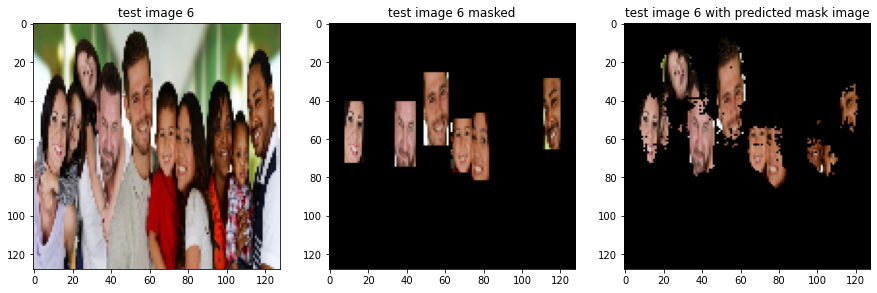

[figure not shown]

[figure not shown]

```python
for i in range(len(test_images)):
    plt.figure(figsize=(15,45))
    plt.subplot(131)
    plt.title("test image %d"%i)
    trueImage = (test_images[i]+1)/2
    plt.imshow(trueImage)
    plt.subplot(132)
    plt.title("test image %d masked"%i)
    masked = cv2.bitwise_and(trueImage,trueImage,mask=test_masks[i].astype('uint8'))
    plt.imshow(masked)
    plt.subplot(133)
    plt.title("test image %d with predicted mask image"%i)
    masked = cv2.bitwise_and(trueImage,trueImage,mask=pred_masks[i].astype('uint8'))
    plt.imshow(masked)
```

## Part B

**DOMAIN:** Entertainment

**• CONTEXT:** Company X owns a movie application and repository which caters movie streaming to millions of users who on subscription basis. Company wants to automate the process of cast and crew information in each scene from a movie such that when a user pauses on the movie and clicks on cast information button, the app will show details of the actor in the scene. Company has an in-house computer vision and multimedia experts who need to detect faces from screen shots from the movie scene. The data labelling is already done. Since there higher time complexity is involved in the  
**• DATA DESCRIPTION:** The dataset comprises of face images.  
**• PROJECT OBJECTIVE:** To create an image dataset to be used by AI team build an image classifier data. Profile images of people are given.

**Steps and tasks:**

1. Read/import images from folder ‘training_images’.
2. Write a loop which will iterate through all the images in the ‘training_images’ folder and detect the faces present on all the images.  
   Hint: You can use ’haarcascade_frontalface_default.xml’ from internet to detect faces which is available open source.
3. From the same loop above, extract metadata of the faces and write into a DataFrame.
4. Save the output Dataframe in .csv format.

```python
# read image names and extract the contents of the zip file
with zipfile.ZipFile('training_images.zip', 'r') as zfile:
    fnames = zfile.filelist
    zfile.extractall('.')
fnames = [f.filename for f in fnames]

# using haarcascade
face_cascade = cv2.CascadeClassifier('haarcascade_frontalface_default.xml')

# detect face bounding boxes
metaArray = []
for i,file in enumerate(fnames): # loop to iterate through all images in folder
    face_image = np.array(Image.open(file)) # read image
    gray = cv2.cvtColor(face_image, cv2.COLOR_BGR2GRAY) # convert 3 channel rgb image to grayscale image
    faces = face_cascade.detectMultiScale(gray) # detect the bounding boxes for faces in the grayscale image
    face_count=len(faces)
    for n,(x, y, w, h) in enumerate(faces):
        metadata = [x,y,w,h,n+1,face_count,file.split('/')[-1]]
        metaArray.append(metadata)

# store the metadata in a pandas dataframe
metaDf = pd.DataFrame(metaArray,columns=['x','y','w','h','nth face','total faces','image name'])

# display few data
display(metaDf.head())

# save the metadata as a csv file
metaDf.to_csv('metadata.csv',index=False)
```

|  | x | y | w | h | nth face | total faces | image name |
| --- | --- | --- | --- | --- | --- | --- | --- |
| 0 | 523 | 139 | 64 | 64 | 1 | 1 | real_00947.jpg |
| 1 | 339 | 412 | 128 | 128 | 1 | 1 | real_01052.jpg |
| 2 | 40 | 130 | 407 | 407 | 1 | 2 | real_01042.jpg |
| 3 | 431 | 267 | 156 | 156 | 2 | 2 | real_01042.jpg |
| 4 | 57 | 113 | 447 | 447 | 1 | 1 | real_00964.jpg |

the extracted metadata was stored in local disk as metadata.csv

## Part C

**• DOMAIN:** Face Recognition  
**• CONTEXT:** Company X intends to build a face identification model to recognise human faces.  
**• DATA DESCRIPTION:** The dataset comprises of images and its mask where there is a human face.  
**• PROJECT OBJECTIVE:** Face Aligned Face Dataset from Pinterest. This dataset contains 10,770 images for 100 people. All images are taken from 'Pinterest' and aligned using dlib library.

**Steps and tasks:**  
1. Unzip, read and Load data(‘PINS.zip’) into session.

```python
# extract the PINS zip file
with zipfile.ZipFile('PINS.zip','r') as zfile:
    zfile.extractall('.') # extract
    flist = zfile.filelist # fetch files list

# extract file paths
fnames = []
for file in flist:
    name = file.filename # retreive file name
    if name.startswith('__MACOSX'): # ignore MAC OS specific files
        continue
    if name.endswith('/'): # ignore folder paths
        continue
    fnames.append(name) # store image paths
```

**Steps and tasks:**

1. Write function to create metadata of the image.
2. Write a loop to iterate through each and every image and create metadata for all the images.

```python
def meta(fpath):
    """returns dictionary of metadata"""
    name = re.split(r'pins_|[//]',fpath)[2]
    return dict(name=name,path=fpath)
```

```python
# test the meta function
meta(fnames[1000])
```

```
{'name': 'Emilia Clarke',
 'path': 'PINS/pins_Emilia Clarke/Emilia Clarke2_1022.jpg'}
```

```python
# loop and create meta data for all images
metaArray = []
for fpath in fnames:
    metaArray.append(meta(fpath))
```

```python
# display few from metaArray
for ind in np.random.randint(0,len(metaArray),(5)):
    print(metaArray[ind])
```

```
{'name': 'Sebastian Stan', 'path': 'PINS/pins_Sebastian Stan/Sebastian Stan79.jpg'}
{'name': 'Martin Starr', 'path': 'PINS/pins_Martin Starr/Martin Starr35.jpg'}
{'name': 'Chris Evans', 'path': 'PINS/pins_Chris Evans/Chris Evans4.jpg'}
{'name': 'Maisie Williams', 'path': 'PINS/pins_Maisie Williams/Maisie Williams127_1068.jpg'}
{'name': 'anne hathaway', 'path': 'PINS/pins_anne hathaway/anne hathaway118.jpg'}
```

**Steps and tasks:**

1. Generate Embeddings vectors on the each face in the dataset.  
   Hint: Use ‘vgg_face_weights.h5’

```python
# define vgg face model topology
def vgg_face():
    model = Sequential()
    model.add(ZeroPadding2D((1,1),input_shape=(224,224, 3)))
    model.add(Convolution2D(64, (3, 3), activation='relu'))
    model.add(ZeroPadding2D((1,1)))
    model.add(Convolution2D(64, (3, 3), activation='relu'))
    model.add(MaxPooling2D((2,2), strides=(2,2)))

    model.add(ZeroPadding2D((1,1)))
    model.add(Convolution2D(128, (3, 3), activation='relu'))
    model.add(ZeroPadding2D((1,1)))
    model.add(Convolution2D(128, (3, 3), activation='relu'))
    model.add(MaxPooling2D((2,2), strides=(2,2)))

    model.add(ZeroPadding2D((1,1)))
    model.add(Convolution2D(256, (3, 3), activation='relu'))
    model.add(ZeroPadding2D((1,1)))
    model.add(Convolution2D(256, (3, 3), activation='relu'))
    model.add(ZeroPadding2D((1,1)))
    model.add(Convolution2D(256, (3, 3), activation='relu'))
    model.add(MaxPooling2D((2,2), strides=(2,2)))

    model.add(ZeroPadding2D((1,1)))
    model.add(Convolution2D(512, (3, 3), activation='relu'))
    model.add(ZeroPadding2D((1,1)))
    model.add(Convolution2D(512, (3, 3), activation='relu'))
    model.add(ZeroPadding2D((1,1)))
    model.add(Convolution2D(512, (3, 3), activation='relu'))
    model.add(MaxPooling2D((2,2), strides=(2,2)))

    model.add(ZeroPadding2D((1,1)))
    model.add(Convolution2D(512, (3, 3), activation='relu'))
    model.add(ZeroPadding2D((1,1)))
    model.add(Convolution2D(512, (3, 3), activation='relu'))
    model.add(ZeroPadding2D((1,1)))
    model.add(Convolution2D(512, (3, 3), activation='relu'))
    model.add(MaxPooling2D((2,2), strides=(2,2)))

    model.add(Convolution2D(4096, (7, 7), activation='relu'))
    model.add(Dropout(0.5))
    model.add(Convolution2D(4096, (1, 1), activation='relu'))
    model.add(Dropout(0.5))
    model.add(Convolution2D(2622, (1, 1)))
    model.add(Flatten())
    model.add(Activation('softmax'))
    return model
```

```python
# instantiate the model
vggFace = vgg_face()

# load trained weights
vggFace.load_weights('vgg_face_weights.h5')

# trim out a submodel from vggFace to extract just embeddings, not the classification
faceEmbed = Model(inputs=vggFace.layers[0].input, outputs=vggFace.layers[-2].output)
```

```python
# generate embeddings for one image
face = np.array(Image.open(metaArray[0].get('path'))) # read image
face = (face/255.0).astype(np.float32) # normalise image
face = cv2.resize(face,(224,224)) # resize to suit vgg_face model
embedding = faceEmbed.predict(np.expand_dims(face,0))[0] # predict embeddings
embedding.shape # review embedding shape
```

[output not shown]

```
(2622,)
```

```python
# loop over all images
def embed(img):
    face = np.array(Image.open(img.get('path')))
    face = (face/255.0).astype(np.float32)
    face = cv2.resize(face,(224,224))
    embedding = faceEmbed.predict(np.expand_dims(face,0))[0]
    img.update(dict(embedding = embedding))
```

```python
%%time
for img in tqdm(metaArray):
    embed(img)
```

```
CPU times: user 47min 56s, sys: 38.6 s, total: 48min 34s
Wall time: 46min 27s
```

**Steps and tasks:**

1. Build distance metrics for identifying the distance between two similar and dissimilar images.

```python
# define distance metric
def distance(embA,embB):
    return np.sum(np.square(embA-embB))
```

```python
def compareImage(a,b):
    img1 = Image.open(metaArray[a].get('path'))
    img2 = Image.open(metaArray[b].get('path'))
    name1 = metaArray[a].get('name')
    name2 = metaArray[b].get('name')
    embA = metaArray[a].get('embedding')
    embB = metaArray[b].get('embedding')
    dist = distance(embA,embB)
    plt.figure(figsize=(10,5))
    plt.suptitle('distance : %.3f'%dist)
    plt.subplot(121)
    plt.title(name1)
    plt.imshow(img1)
    plt.subplot(122)
    plt.title(name2)
    plt.imshow(img2)
```

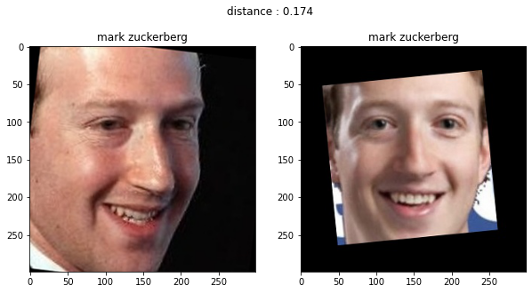

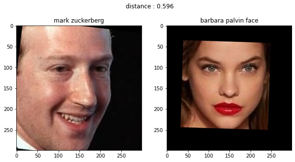

```python
# lets test the distance measures
compareImage(40,41)
compareImage(40,401)
```

**Steps and tasks:**

1. Use PCA for dimensionality reduction.
2. Build an SVM classifier in order to map each image to its right person.

```python
# stack a numpy array of embeddings as the independant variable
# list the respective names as target class
X = np.array([m.get('embedding') for m in metaArray])
Y = np.array([m.get('name') for m in metaArray])
```

```python
# split train & test datasets
X_train, X_test, Y_train, Y_test = train_test_split(X, Y,test_size=0.10, # split ratio of 90:10
                                                    random_state=129) # random seed
```

```python
# standardize
scl=StandardScaler()
X_train = scl.fit_transform(X_train)
X_test = scl.transform(X_test) # transform only
```

```python
# apply PCA with 20 components
pca = PCA(n_components=20)
pca.fit(X_train);

# calculate explained variance cumulative summation
exp_var=np.cumsum(pca.explained_variance_ratio_)
```

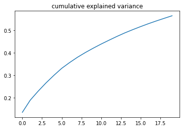

```python
plt.figure()
plt.title('cumulative explained variance')
plt.plot(exp_var);
```

seems like the 20 components doesn't justify the variance of the dataset  
hence lets extract more components

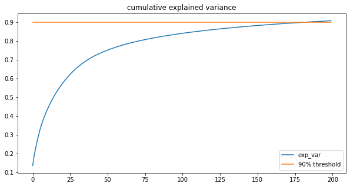

```python
# apply PCA with more components
pca = PCA(n_components=200)
pca.fit(X_train);

# calculate explained variance cumulative summation
exp_var=np.cumsum(pca.explained_variance_ratio_)

# visualise
plt.figure(figsize=(10,5))
plt.title('cumulative explained variance')
plt.plot(exp_var,label='exp_var')
plt.plot(np.ones(len(exp_var))*0.9,label='90% threshold')
plt.legend()
plt.show()
```

```python
for i,evar in enumerate(exp_var):
    if evar>=0.9:
        print("nComponets: %d"%i, " cum_var: %.3f"%evar)
        break
```

```
nComponets: 181  cum_var: 0.900
```

the cummulative explained variance reaches 90% for 181 components  
lets build again the PCA for 181 components and proceed further

```python
# apply PCA with 181 components
pca = PCA(n_components=181)
X_train = pca.fit_transform(X_train)
X_test = pca.transform(X_test)
```

```python
# encode target variables
le = LabelEncoder()
Y_train = le.fit_transform(Y_train)
Y_test = le.transform(Y_test)
```

```python
# confirm shapes all variables
X_train.shape, Y_train.shape, X_test.shape, Y_test.shape
```

```
((9693, 181), (9693,), (1077, 181), (1077,))
```

```python
# build a SVC for the above dataset
classifer = SVC()
classifer.fit(X_train,Y_train) #fit
print("accuracy score: %.6f"%classifer.score(X_test,Y_test)) #score
```

```
accuracy score: 0.952646
```

thats a pretty good accuracy score for the test images  
lets read & predict the names of test images

**Steps and tasks:**

1. Import and display the the test images.  
   Hint: ‘Benedict Cumberbatch9.jpg’ and ‘Dwayne Johnson4.jpg’ are the test images.
2. Use the trained SVM model to predict the face on both test images.

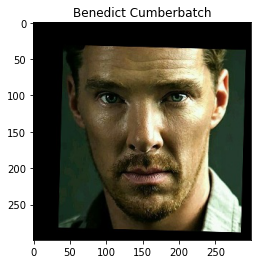

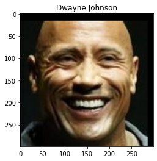

```python
test_images = ['Benedict Cumberbatch9.jpg','Dwayne Johnson4.jpg']
for test in test_images:
    face = np.array(Image.open(test))
    face2 = (face/255.0).astype(np.float32)
    face2 = cv2.resize(face2,(224,224))
    embedding = faceEmbed.predict(np.expand_dims(face2,0))
    test_emb = scl.transform(embedding)
    test_emb = pca.transform(test_emb)
    prediction = classifer.predict(test_emb)
    prediction = le.inverse_transform(prediction)
    plt.figure()
    plt.title(prediction[0])
    plt.imshow(face)
```